##### Copyright 2020 The TensorFlow Authors.

```python
#@title Licensed under the Apache License, Version 2.0 (the "License");
# you may not use this file except in compliance with the License.
# You may obtain a copy of the License at
#
# https://www.apache.org/licenses/LICENSE-2.0
#
# Unless required by applicable law or agreed to in writing, software
# distributed under the License is distributed on an "AS IS" BASIS,
# WITHOUT WARRANTIES OR CONDITIONS OF ANY KIND, either express or implied.
# See the License for the specific language governing permissions and
# limitations under the License.
```

# Intro to Autoencoders

[View on TensorFlow.org](https://www.tensorflow.org/tutorials/generative/autoencoder)

[Run in Google Colab](https://colab.research.google.com/github/tensorflow/docs/blob/master/site/en/tutorials/generative/autoencoder.ipynb)

[figure not shown]

View source on GitHub

[Download notebook](https://storage.googleapis.com/tensorflow_docs/docs/site/en/tutorials/generative/autoencoder.ipynb)

An autoencoder is a special type of neural network that is trained to copy its input to its output. For example, given an image of a handwritten digit, an autoencoder first encodes the image into a lower dimensional latent representation, then decodes the latent representation back to an image. An autoencoder learns to compress the data while minimizing the reconstruction error.

To learn more about autoencoders, please consider reading chapter 14 from [Deep Learning](https://www.deeplearningbook.org/) by Ian Goodfellow, Yoshua Bengio, and Aaron Courville.

## Import TensorFlow and other libraries

```python
%config Completer.use_jedi = False

import logging
import matplotlib.pyplot as plt
import numpy as np
import pandas as pd
import tensorflow as tf
import tensorflow_transform as tft
import tensorflow_transform.beam.impl as tft_beam
from sklearn.metrics import accuracy_score, precision_score, recall_score
from sklearn.model_selection import train_test_split
from tensorflow.keras import layers, losses
from tensorflow.keras.datasets import fashion_mnist
from tensorflow.keras.models import Model
import tensorflow_probability as tfp
import tensorflow_transform as tft
from sklearn.decomposition import PCA
from sklearn.preprocessing import StandardScaler
seed = 100
np.random.seed(seed)
tf.random.set_seed(seed)
```

## Load the dataset

To start, you will train the basic autoencoder using the Fashon MNIST dataset. Each image in this dataset is 28x28 pixels.

```python
(x_train, _), (x_test, _) = fashion_mnist.load_data()

x_train = x_train.astype('float32') / 255.
x_test = x_test.astype('float32') / 255.

print (x_train.shape)
print (x_test.shape)
```

```
(60000, 28, 28)
(10000, 28, 28)
```

## First example: Basic autoencoder

[figure not shown]

To define your model, use the [Keras Model Subclassing API](https://www.tensorflow.org/guide/keras/custom_layers_and_models).

```python
latent_dim = 16

class Autoencoder(Model):
  def __init__(self, latent_dim):
    super(Autoencoder, self).__init__()
    self.latent_dim = latent_dim
    self.encoder = tf.keras.Sequential([
      layers.Flatten(),
      layers.Dense(latent_dim, activation='relu'),
    ])
    self.decoder = tf.keras.Sequential([
      layers.Dense(784, activation='sigmoid'),
      layers.Reshape((28, 28))
    ])

  def call(self, x):
    encoded = self.encoder(x)
    decoded = self.decoder(encoded)
    return decoded

autoencoder = Autoencoder(latent_dim)
```

```python
autoencoder.compile(optimizer='adam', loss=losses.MeanSquaredError())
```

Train the model using `x_train` as both the input and the target. The `encoder` will learn to compress the dataset from 784 dimensions to the latent space, and the `decoder` will learn to reconstruct the original images. .

```python
autoencoder.fit(x_train, x_train,
                epochs=10,
                shuffle=True,
                validation_data=(x_test, x_test))
```

```
<tensorflow.python.keras.callbacks.History at 0x7fd5f2e03438>
```

Now that the model is trained, let's test it by encoding and decoding images from the test set.

```python
encoded_imgs = autoencoder.encoder(x_test).numpy()
decoded_imgs = autoencoder.decoder(encoded_imgs).numpy()
```

[figure not shown]

```python
n = 10
plt.figure(figsize=(20, 4))
for i in range(n):
  # display original
  ax = plt.subplot(2, n, i + 1)
  plt.imshow(x_test[i])
  plt.title("original")
  plt.gray()
  ax.get_xaxis().set_visible(False)
  ax.get_yaxis().set_visible(False)

  # display reconstruction
  ax = plt.subplot(2, n, i + 1 + n)
  plt.imshow(decoded_imgs[i])
  plt.title("reconstructed")
  plt.gray()
  ax.get_xaxis().set_visible(False)
  ax.get_yaxis().set_visible(False)
plt.show()
```

```python
(train_images2, train_labels2), (test_images2, test_labels2) = fashion_mnist.load_data()
```

```python
class_names = ['T-shirt/top', 'Trouser', 'Pullover', 'Dress', 'Coat',
               'Sandal', 'Shirt', 'Sneaker', 'Bag', 'Ankle boot']
```

```python
def fix_non_positive_definite_matrix(A,eps=0.01):
    logger = logging.getLogger('fix_non_positive_definite_matrix')
    e,v = tf.linalg.eigh(A)
    e_fix = e * tf.cast(tf.greater(e,0),dtype=tf.float32)+eps *tf.cast(tf.less_equal(e,0),dtype=tf.float32)
    A_fix = tf.matmul(v,tf.matmul(tf.linalg.diag(e_fix),tf.transpose(v)))
    A_norm = tf.norm(A)
    A_fix_norm = tf.norm(A_fix)
    corr_err = tf.math.round(1.0*tf.math.abs(A_norm-A_fix_norm)/A_norm,10)
    logger.info(f'Correction error : {corr_err}')
    logger.info(f'VV^T after fixing = {tf.linalg.diag_part(tf.matmul(v,tf.transpose(v)))}')
    return A_fix
```

```python
def calc_z_likelihood(z,raxis = 0):
    logger = logging.getLogger('calc_z_likelihood')
    sample_mean = tf.reduce_max(input_tensor=z,axis=raxis)
    sample_cov = tfp.stats.covariance(x=z)
    sample_cov_fixed  = fix_non_positive_definite_matrix(sample_cov)

    e,v = tf.linalg.eigh(tensor=sample_cov_fixed)
    logger.info(f'Eigenvalues for sample covariance marix : shape =  {e.shape} , values = {e}')

    L = tf.linalg.cholesky(input=sample_cov_fixed)

    sample_var = tf.linalg.diag_part(input=sample_cov)+0.1
#     logger.debug(f'sample_mean = {sample_mean.shape}')
#     logger.debug(f'sample_cov = {sample_cov.shape}')
    logger.debug(f'sample_var = {sample_var}')
    mvn_diag = tfp.distributions.MultivariateNormalDiag(loc=sample_mean,scale_diag=sample_var)
    mvn_tri = tfp.distributions.MultivariateNormalTriL(loc=sample_mean,scale_tril=L)
    log_p_diag = tf.reduce_sum(mvn_diag.log_prob(z))
    log_p_tri = tf.reduce_sum(mvn_tri.log_prob(z))
    logger.debug(f' log_p_tri = {log_p_tri}')
    logger.debug(f' log_p_diag = {log_p_diag}')
    logger.debug(f'Ratio log_p_tri / log_p_diag = {np.round(log_p_tri/log_p_diag,3)}')
```

```
INFO:Main:Training autoencoder for label 0 with name T-shirt/top
```

[output not shown]

[output cut: 310 more lines]

[output not shown]

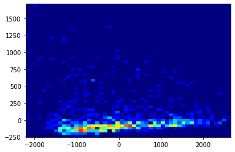

```
INFO:Main:Z shape of auto_encoder_T-shirt/top = (1000, 16)
INFO:fix_non_positive_definite_matrix:Correction error : 0.0
INFO:fix_non_positive_definite_matrix:VV^T after fixing = [1.         1.0000001  0.99999994 1.0000004  1.0000001  1.0000002
 1.         1.         1.         1.0000001  1.0000002  1.0000007
 1.         0.99999994 0.99999994 0.9999993 ]
INFO:calc_z_likelihood:Eigenvalues for sample covariance marix : shape =  (16,) , values = [-3.63858299e-09  1.56389942e-04  1.00000007e-02  1.01353759e-02
  2.57020183e-02  3.29643518e-01  1.86148572e+00  3.01993160e+01
  3.82404449e+02  1.82049255e+03  2.36683618e+03  2.39063574e+03
  2.63115625e+03  3.61514868e+03  5.01645117e+04  1.01838444e+06]
DEBUG:calc_z_likelihood:sample_var = [1.0000000e-01 3.8134628e+01 2.1090377e+04 4.8815349e-01 6.6742266e+03
 1.0000000e-01 1.5236253e+05 1.3466886e-01 2.8685066e+04 9.6396133e+04
 1.0000000e-01 2.0181990e+00 1.0000000e-01 1.9486845e+05 5.8067831e+05
 9.9376874e+02]
DEBUG:calc_z_likelihood: log_p_tri = -1463735.5
DEBUG:calc_z_likelihood: log_p_diag = -1876932.375
DEBUG:calc_z_likelihood:Ratio log_p_tri / log_p_diag = 0.7799999713897705
INFO:Main:Training autoencoder for label 1 with name Trouser
```

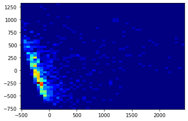

```
INFO:Main:Z shape of auto_encoder_Trouser = (1000, 16)
INFO:fix_non_positive_definite_matrix:Correction error : 0.0
INFO:fix_non_positive_definite_matrix:VV^T after fixing = [0.9999999 1.0000004 0.9999998 0.9999995 1.0000002 1.0000001 1.0000001
 0.9999996 1.0000001 0.9999999 1.0000001 0.9999999 1.0000002 1.0000002
 1.        1.0000001]
INFO:calc_z_likelihood:Eigenvalues for sample covariance marix : shape =  (16,) , values = [-9.2763454e-05 -7.9505366e-18  2.1969703e-04  9.9189002e-03
  9.9999998e-03  2.3648964e-01  8.8627484e+02  9.5654572e+02
  1.1856892e+03  1.5188159e+03  1.9997631e+03  2.1618936e+03
  3.7078911e+03  1.8492182e+04  1.3678106e+05  1.9434534e+05]
DEBUG:calc_z_likelihood:sample_var = [1.4613523e+04 1.6384904e+04 2.5630279e+04 8.0208289e+04 1.0000000e-01
 2.7836369e+04 1.0000000e-01 6.4054230e+04 1.0000000e-01 5.0420383e+04
 3.3919299e-01 1.0000000e-01 1.9687178e+04 3.2256691e+04 1.0000000e-01
 3.0944811e+04]
DEBUG:calc_z_likelihood: log_p_tri = -620026.125
DEBUG:calc_z_likelihood: log_p_diag = -1145087.5
DEBUG:calc_z_likelihood:Ratio log_p_tri / log_p_diag = 0.5410000085830688
INFO:Main:Training autoencoder for label 2 with name Pullover
```

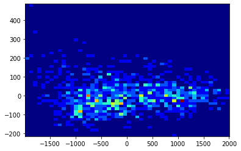

```
INFO:Main:Z shape of auto_encoder_Pullover = (1000, 16)
INFO:fix_non_positive_definite_matrix:Correction error : 0.0
INFO:fix_non_positive_definite_matrix:VV^T after fixing = [1.         1.0000002  1.0000001  1.0000006  1.0000005  1.
 0.99999994 1.0000002  1.0000002  1.0000005  1.0000002  1.
 0.9999994  1.         1.0000001  1.        ]
INFO:calc_z_likelihood:Eigenvalues for sample covariance marix : shape =  (16,) , values = [6.9929323e-05 2.5893273e-04 4.5642094e-04 9.7392015e-03 9.9999998e-03
 9.9999998e-03 1.0017193e-02 8.3349608e-02 1.3711123e+03 1.7835588e+03
 2.0775251e+03 2.4974177e+03 2.8693726e+03 2.9735413e+03 5.9324292e+03
 7.5005675e+05]
DEBUG:calc_z_likelihood:sample_var = [1.0000000e-01 8.9752469e+04 1.0000000e-01 1.0000000e-01 1.0000000e-01
 1.0000000e-01 2.6251107e+04 1.4443958e+05 1.0000000e-01 1.0000000e-01
 1.9883094e+05 2.3404038e+05 1.8651785e+04 4.0444738e+04 1.7151939e+04
 1.0000000e-01]
DEBUG:calc_z_likelihood: log_p_tri = -42391.828125
DEBUG:calc_z_likelihood: log_p_diag = -84499.0
DEBUG:calc_z_likelihood:Ratio log_p_tri / log_p_diag = 0.5019999742507935
INFO:Main:Training autoencoder for label 3 with name Dress
```

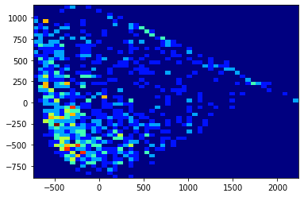

```
INFO:Main:Z shape of auto_encoder_Dress = (1000, 16)
INFO:fix_non_positive_definite_matrix:Correction error : 0.0
INFO:fix_non_positive_definite_matrix:VV^T after fixing = [1.0000001  0.99999994 1.0000001  1.         1.0000002  1.
 0.9999999  1.         1.0000002  1.0000002  0.9999998  1.
 1.         1.         1.         1.        ]
INFO:calc_z_likelihood:Eigenvalues for sample covariance marix : shape =  (16,) , values = [6.1926155e-05 9.9999998e-03 9.9999998e-03 9.9999998e-03 9.9999998e-03
 1.0000079e-02 1.0057469e-02 7.9667427e-02 2.3770241e-01 3.0748415e-01
 1.9650365e+03 2.7073279e+03 5.6869551e+03 6.0670459e+03 2.2479234e+05
 3.0677200e+05]
DEBUG:calc_z_likelihood:sample_var = [5.6939195e+04 1.0783603e+05 3.3806312e-01 1.0000000e-01 1.0000000e-01
 3.8749551e+04 1.0000000e-01 1.8009019e-01 3.7698371e+04 8.1438422e+04
 2.2533005e+05 4.0982819e-01 1.0000000e-01 1.0000000e-01 1.0000000e-01
 1.0000000e-01]
DEBUG:calc_z_likelihood: log_p_tri = -1520938.125
DEBUG:calc_z_likelihood: log_p_diag = -3027508.5
DEBUG:calc_z_likelihood:Ratio log_p_tri / log_p_diag = 0.5019999742507935
INFO:Main:Training autoencoder for label 4 with name Coat
```

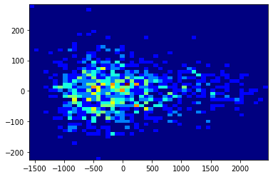

```
INFO:Main:Z shape of auto_encoder_Coat = (1000, 16)
INFO:fix_non_positive_definite_matrix:Correction error : 0.0
INFO:fix_non_positive_definite_matrix:VV^T after fixing = [1.0000005 1.0000004 1.0000001 1.0000004 1.0000005 1.0000005 1.
 1.        1.0000004 1.        1.        1.        1.        1.
 1.        1.0000004]
INFO:calc_z_likelihood:Eigenvalues for sample covariance marix : shape =  (16,) , values = [-6.1435079e-05 -4.6662257e-10  1.6588866e-04  9.9572288e-03
  9.9999970e-03  9.9999970e-03  9.9999970e-03  9.9999970e-03
  9.9999970e-03  9.9999988e-03  1.0000006e-02  1.8899368e+03
  2.0291846e+03  2.8258142e+03  3.8053911e+03  5.6090219e+05]
INFO:Main:Training autoencoder for label 5 with name Sandal
```

```
Cholesky decomposition was not successful. The input might not be valid. [Op:Cholesky]
```

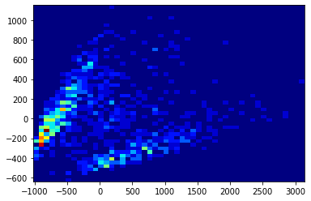

```
INFO:Main:Z shape of auto_encoder_Sandal = (1000, 16)
INFO:fix_non_positive_definite_matrix:Correction error : 0.0
INFO:fix_non_positive_definite_matrix:VV^T after fixing = [1.         1.         1.0000005  1.0000001  0.9999999  1.
 0.99999964 1.0000004  0.9999999  1.         1.0000004  1.
 1.0000006  0.9999998  1.         0.9999998 ]
INFO:calc_z_likelihood:Eigenvalues for sample covariance marix : shape =  (16,) , values = [9.9298963e-03 8.0005150e+00 9.2325262e+02 1.7837473e+03 2.0791167e+03
 2.2100188e+03 2.5800803e+03 2.7423557e+03 3.1938169e+03 3.6896902e+03
 4.0667495e+03 7.2512935e+03 8.6119814e+03 3.2422584e+04 1.0068933e+05
 5.5449956e+05]
DEBUG:calc_z_likelihood:sample_var = [6.6677867e+04 1.8383011e+05 8.1565093e+03 2.4051250e+04 2.9760850e+04
 4.8394293e+04 7.7176609e+04 3.3741438e+04 3.7850105e+04 2.4902623e+04
 2.9771650e+03 8.7927180e+04 1.4297139e+04 8.2547684e+00 1.0000000e-01
 8.7001781e+04]
DEBUG:calc_z_likelihood: log_p_tri = -603596.375
DEBUG:calc_z_likelihood: log_p_diag = -203706.765625
DEBUG:calc_z_likelihood:Ratio log_p_tri / log_p_diag = 2.9630000591278076
INFO:Main:Training autoencoder for label 6 with name Shirt
```

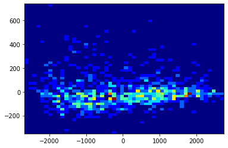

```
INFO:Main:Z shape of auto_encoder_Shirt = (1000, 16)
INFO:fix_non_positive_definite_matrix:Correction error : 0.0
INFO:fix_non_positive_definite_matrix:VV^T after fixing = [0.9999999  1.0000001  1.0000004  1.0000001  1.0000005  0.9999997
 1.0000004  1.0000001  0.99999976 1.0000004  0.9999997  1.
 1.         1.         1.         0.9999995 ]
INFO:calc_z_likelihood:Eigenvalues for sample covariance marix : shape =  (16,) , values = [-3.9790815e-04 -2.2379975e-06  2.1382618e-04  1.0000001e-02
  1.0000002e-02  1.0000002e-02  5.6268811e+00  7.7740814e+01
  2.3702074e+02  1.9019482e+03  2.2451655e+03  3.1518076e+03
  4.4451982e+03  4.8759326e+03  1.4622958e+04  1.5494935e+06]
DEBUG:calc_z_likelihood:sample_var = [9.1752538e+05 5.8603506e+00 6.1036277e+04 8.5428375e+04 1.0000000e-01
 4.6460980e+04 1.0000000e-01 3.4480461e+04 8.2112625e+01 1.0000000e-01
 1.2183268e+04 2.6254971e+02 1.0000000e-01 1.0000000e-01 1.0000000e-01
 4.2359306e+05]
DEBUG:calc_z_likelihood: log_p_tri = -512339.375
DEBUG:calc_z_likelihood: log_p_diag = -143707.46875
DEBUG:calc_z_likelihood:Ratio log_p_tri / log_p_diag = 3.565000057220459
INFO:Main:Training autoencoder for label 7 with name Sneaker
```

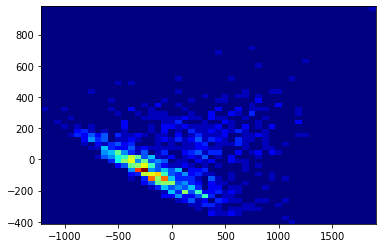

```
INFO:Main:Z shape of auto_encoder_Sneaker = (1000, 16)
INFO:fix_non_positive_definite_matrix:Correction error : 0.0
INFO:fix_non_positive_definite_matrix:VV^T after fixing = [0.9999999 1.0000002 1.0000005 1.0000001 1.0000002 1.0000001 1.000001
 1.        1.0000005 0.9999999 1.0000004 1.0000002 1.0000004 1.0000005
 0.9999999 1.       ]
INFO:calc_z_likelihood:Eigenvalues for sample covariance marix : shape =  (16,) , values = [-4.3098474e-04 -2.0357377e-04 -6.6082601e-10  2.4774547e-08
  9.8004835e-03  9.9999998e-03  9.5889191e+02  1.2084755e+03
  1.4611327e+03  1.5610056e+03  2.0665396e+03  2.2674954e+03
  3.4152375e+03  6.2261001e+03  2.9415717e+04  1.8521353e+05]
DEBUG:calc_z_likelihood:sample_var = [8.8084102e+03 3.3681984e+04 1.0000000e-01 1.4311186e+04 1.0000000e-01
 1.2549039e+04 1.0000000e-01 2.0917773e+04 1.7626238e+04 1.7159916e+04
 1.0000000e-01 1.0000000e-01 1.2647830e+04 4.8206457e+04 4.7886082e+04
 1.0000000e-01]
DEBUG:calc_z_likelihood: log_p_tri = -224664.15625
DEBUG:calc_z_likelihood: log_p_diag = -99888.6171875
DEBUG:calc_z_likelihood:Ratio log_p_tri / log_p_diag = 2.249000072479248
INFO:Main:Training autoencoder for label 8 with name Bag
```

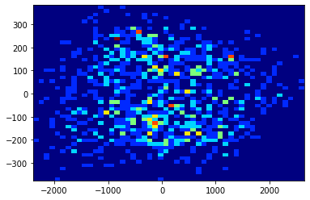

```
INFO:Main:Z shape of auto_encoder_Bag = (1000, 16)
INFO:fix_non_positive_definite_matrix:Correction error : 0.0
INFO:fix_non_positive_definite_matrix:VV^T after fixing = [1.0000004 1.0000002 0.9999995 1.0000001 1.0000002 1.0000002 1.0000005
 1.0000005 1.        1.0000002 1.0000001 1.0000005 1.0000006 1.0000001
 1.0000008 1.       ]
INFO:calc_z_likelihood:Eigenvalues for sample covariance marix : shape =  (16,) , values = [2.7529194e-03 1.0015565e-02 1.1835865e-02 8.9868389e-02 1.3566441e+02
 2.3329719e+03 2.4921543e+03 2.8340901e+03 3.0809856e+03 3.3741338e+03
 3.7391614e+03 4.7195337e+03 7.0229336e+03 8.5642100e+03 2.5105350e+04
 9.2305200e+05]
DEBUG:calc_z_likelihood:sample_var = [1.02530352e+05 1.33189375e+05 1.00000001e-01 1.00000001e-01
 1.92307621e-01 1.00000001e-01 2.46642871e+04 8.34179219e+04
 3.69945664e+04 1.05022164e+05 4.12372148e+04 4.18369883e+04
 7.28655703e+04 2.44205391e+05 1.46111771e+02 1.00344375e+05]
DEBUG:calc_z_likelihood: log_p_tri = -495761.0
DEBUG:calc_z_likelihood: log_p_diag = -1047950.625
DEBUG:calc_z_likelihood:Ratio log_p_tri / log_p_diag = 0.4729999899864197
INFO:Main:Training autoencoder for label 9 with name Ankle boot
```

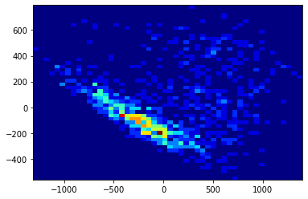

```
INFO:Main:Z shape of auto_encoder_Ankle boot = (1000, 16)
INFO:fix_non_positive_definite_matrix:Correction error : 0.0
INFO:fix_non_positive_definite_matrix:VV^T after fixing = [1.        1.        1.0000001 1.0000006 1.0000004 1.0000004 1.0000004
 1.0000005 0.9999998 0.9999999 1.0000004 1.0000004 1.0000005 1.
 1.0000002 0.9999999]
INFO:calc_z_likelihood:Eigenvalues for sample covariance marix : shape =  (16,) , values = [-1.4539730e-03  2.1502063e-10  1.3323895e-09  1.0792854e-06
  4.6321740e-03  9.9654384e-03  9.9999998e-03  1.0000003e-02
  7.9613128e+00  1.4065539e+01  1.8545461e+03  2.3997356e+03
  2.9864868e+03  3.6010693e+03  5.6240109e+04  2.3605189e+05]
DEBUG:calc_z_likelihood:sample_var = [1.0000000e-01 5.9339449e+04 1.0000000e-01 1.0000000e-01 2.1603277e+04
 1.0000000e-01 1.4793855e+01 8.2318878e+00 1.0000000e-01 4.6849887e+04
 1.0000000e-01 1.0000000e-01 6.2740180e+04 1.0000000e-01 6.4643645e+04
 4.7957012e+04]
DEBUG:calc_z_likelihood: log_p_tri = -989687.9375
DEBUG:calc_z_likelihood: log_p_diag = -154826.625
DEBUG:calc_z_likelihood:Ratio log_p_tri / log_p_diag = 6.392000198364258
```

```python
unique_labels = np.unique(train_labels2)
logging.basicConfig(level=logging.DEBUG)
logger = logging.getLogger('Main')

auto_encoders = dict()
for label in unique_labels:
    train_idx = train_labels2==label
    test_idx = test_labels2 == label

    train_images_label = train_images2[train_idx,:,:]
    test_images_label = test_images2[test_idx,:,:]
#     print(class_names[label])
#     plt.imshow(train_images_label[0,:,:])
#     plt.show()
    logger.info(f'Training autoencoder for label {label} with name {class_names[label]}')
    auto_encoders[label] = autoencoder = Autoencoder(latent_dim)
    auto_encoders[label].compile(optimizer='adam', loss=losses.MeanSquaredError())
    auto_encoders[label].fit(train_images_label, train_images_label,
                epochs=10,
                shuffle=True,
                validation_data=(test_images_label, test_images_label))

    z = auto_encoders[label].encoder(test_images_label)
    if z.shape[0] >2:
        s = StandardScaler()
        z_scaled = s.fit(z)
        pca = PCA(n_components=2)
        z_pca = pca.fit_transform(z)
        z1 = z_pca[:,0]
        z2 = z_pca[:,1]
    elif z.shape[0] == 2:
        z1 = z[:,0].numpy()
        z2 = z[:,1].numpy()
    else:
        raise ValueError('Z shape must be >=2')
    plt.hist2d(z1, z2, bins=(50, 50), cmap=plt.cm.jet)
    plt.show()

    logger.info(f'Z shape of auto_encoder_{class_names[label]} = {z.shape}')
    try:
        calc_z_likelihood(z=z)
    except Exception as e:
        print(e)
        continue
```

```python
# measure of matrix diagonality
# https://math.stackexchange.com/a/1392524
```

Handling the problem of "Cholesky decomposition was not successful" https://www.tensorflow.org/probability/examples/TensorFlow_Probability_Case_Study_Covariance_Estimation#using_the_cholesky_decomposition_of_the_covariance_matrix

## Correcting sample cov matrix to be positive definite

1. https://math.stackexchange.com/a/54820
2. Algo 2.1 calculate eigenval and vec

   2.2 for the eigenval vector, calculate the norm of -ve values over all values and calculate error

   2.3 set all -ve values to eps > 0 (eps is small)

   2.4 Generate using eigne value decomposition A_bar = V D V_T and compare A_bar with original A

   the idea to re-generate a close symmetric postive definite approximate covariance matrix